# Ford GoBike Trip Duration per User Type, Age, and Gender

## by Shahad Al-Khalifa

## Investigation Overview

> In this presentation, we wanted to investigate the duration of trips and how it changes with respect to the user type, age, and gender. Thus, three factor will be investigated the user type (Customer or Subscriber), gender (male, female, or other), and age.

## Dataset Overview

> The dataset has 183412 bike rides that happened in the San Francisco Bay Area. The dataset has 16 features, some of them are:
> - `duration_sec`: The duration of the trip in seconds.
> - `start_time` and `end_time` for the bike rides.
> - `start_station_name` and `end_station_name`, as well as latitude and longitude.
> - `user_type` of either a subscriber or a customer.
> - Some information of the members such as their gender and birth year.

> After my modifications the dataset has 174880 bike rides and 21 features. The added features are the `age`, `start_date`, `end_date`, `start_day`, and `end_day`, since I want to investigate them further.

## Average Trip Duration Based on User Type

> The average trip duration of users is longer for customers in comparison to subscribers.

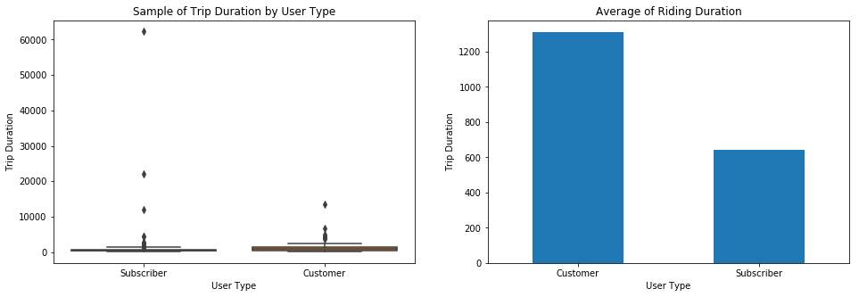

## Average Trip Duration Based on User Age

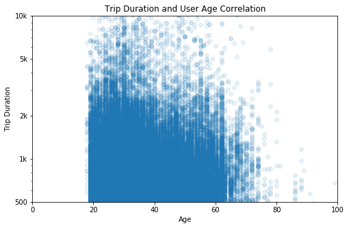

## Average Trip Duration Based on User Gender

> The trip duration of female users is more than male users with an average of 779 seconds, wheras male users have an average of 672 seconds of trip durations. However, Other gender tops male and female with the trip duration frequency having an average of 997 seconds.

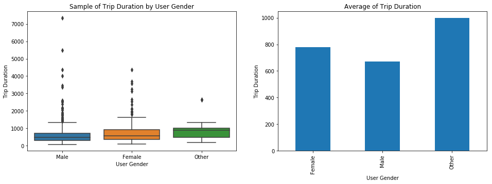